# Effort Throttling and Endogenous Prices

Ernesto Carrella

August 13, 2015

## Effort and Prices

Here I want to briefly investigate how fishers change their effort in response to market signals. I focus on the only meaningful measure of effort we have in the model so far which is how often do agents go out fishing.  
Fishers have a fixed probability of departing from their port each hour. The higher it is the higher the effort.

It’s relatively easy to cook up numbers such that going out is either always profitable or it never is. So for example in the next picture I set a market price for fish too low to cover for gas and other variable costs. Agents learn to lower their effort to 0 over time:

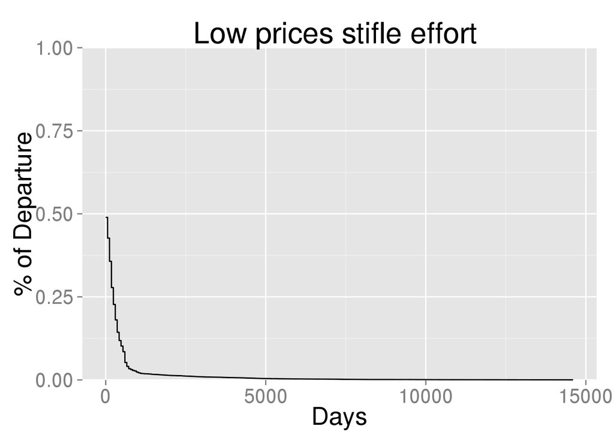

Similarly if the price is high enough agents never spend more than an hour at the dock because to do so is a waste (there is no biomass impact from fishing in these examples):

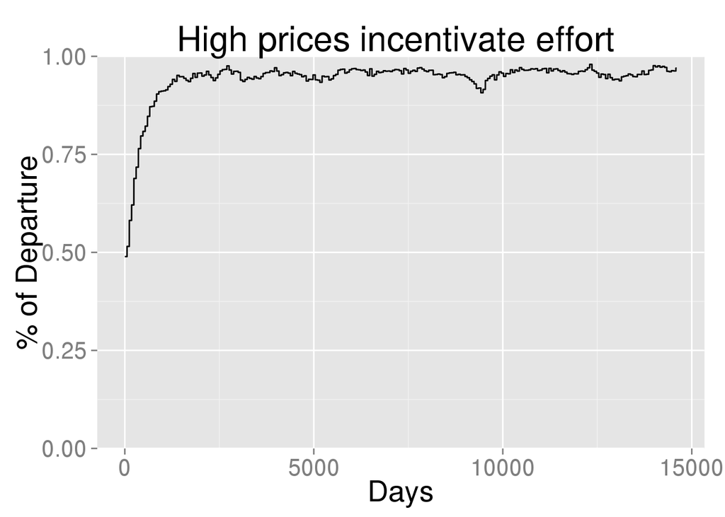

## Variable prices

A more interesting set of results emerges if we let prices vary with the supply. So assume there is a fixed daily demand of fish such that: $p_t = 10-0.001*q_t$ Where $p_t$ is price at day $t$ and $q_t$ are catches sold at port that day. Now market prices work as a rudimentary balancing system: the higher the effort the lower the fish prices which should incentivate fishers to lower their effort. This in turn will raise prices until an equilibrium is reached.

I collect three sample runs where the prices are endogenous and show what happens to effort through 80 years of simulation:

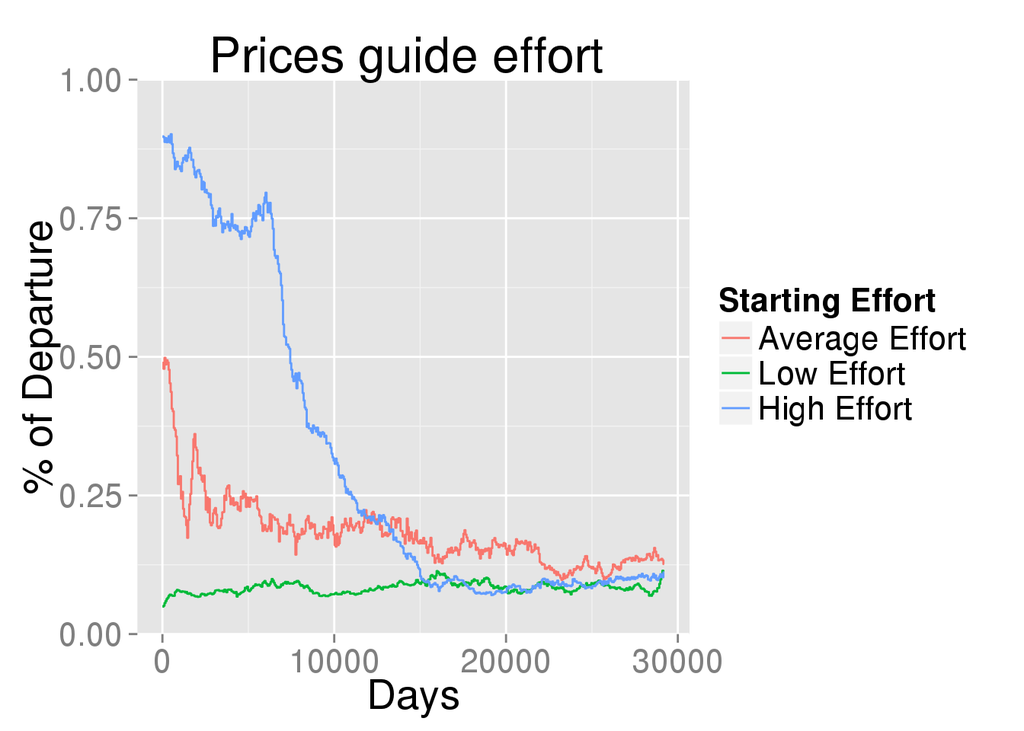

As you can see, regardless of starting conditions, a “steady state” effort emerges; to this steady state corresponds to an equilibrium price of about 4$:

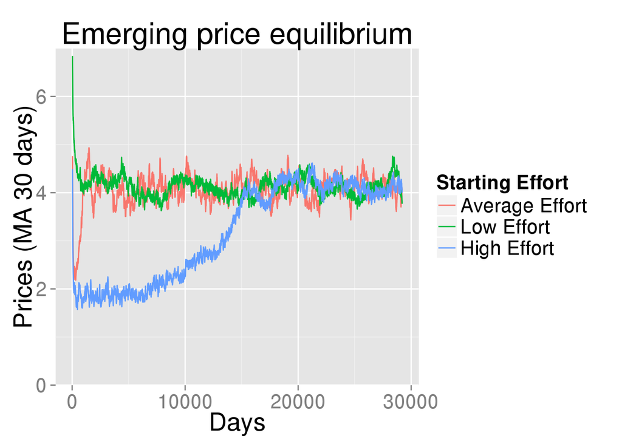

Notice however the long time it takes for equilibrium to emerge. This is due to how often I let agents tweak their effort levels but it has strong implications.  
If the biomass was not fixed but rather finite then the relative speed of adjustment of the biology and the economy would drive the results: do steady state prices emerge before all the fish is dead?